# Threshold Calibration for Binary Outcomes via the GLM Approximation

- Show All Code
- Hide All Code
- View Source

Extending the Section 2.1 Framework to Logistic Regression

Author

Larry F. Leon

Published

April 3, 2026

# 1 The GLM Approximation

## 1.1 Parallel to Section 2.1

For the Cox model, the Section 2.1 approximation uses the asymptotic normality of the score statistic: $\hat\beta_s \approx (4/d) \tilde L_d(0) \sim N(\beta, 4/d)$. For split-halves: $\hat\beta^1_s, \hat\beta^2_s \sim N(\beta, 8/d)$ independently.

For a canonical GLM with treatment as the sole covariate, the MLE satisfies exactly the same structure via Fisher information. With balanced arms ($n_1 = n_0 = n_H/2$):

$$\text{Var}(\hat\beta_{\text{full}}) = \frac{4}{d_{\text{eff}}},
\qquad
\text{Var}(\hat\beta_{\text{half}}) = \frac{8}{d_{\text{eff}}}$$

where $d_{\text{eff}}$ is the effective information:

| Family | $d_{\text{eff}}$ | Analogous to |
| --- | --- | --- |
| Cox | $d = n_H(1-p_c)$ | Number of events |
| Binomial (logit) | $n_H \bar p(1-\bar p)$ | Bernoulli information |
| Poisson (log) | $D$ (total events) | Number of events |
| Gaussian (identity) | $n_H / \sigma^2$ | Precision-weighted n |

The detection probability for a **specific subgroup** with true effect $\beta = \log(\theta^\dagger(H))$ is:

$$p(c_1, c_2; d_{\text{eff}}, \theta^\dagger(H)) =
P(W_1 + W_2 \ge 2\log c_1, \;\min(W_1, W_2) \ge \log c_2)$$

with $W_1, W_2 \stackrel{\text{iid}}{\sim} N(\log \theta^\dagger(H), \; 8/d_{\text{eff}})$.

This gives:

- **Type-I error** (per-subgroup): $p(c_1, c_2; d_{\text{eff}}, 1)$ with $\beta = 0$
- **Power**: $p(c_1, c_2; d_{\text{eff}}, \theta^\dagger(H))$ for the true harm subgroup

The thresholds are then chosen so that $p(c_1, c_2; d_{\text{eff}}, 1) \approx 10\%$ and $p(c_1, c_2; d_{\text{eff}}, \theta^\dagger(H))$ is acceptably high, and **validated by simulation**.

## 1.2 Implementation

```r
# Use compute_detection_probability_glm() and d_eff_*() helpers
# from forestsearch (installed in R/truefind_asymptotic_glm.R).
# These implement equation (3) extended to GLM via d_eff.
#
# Shorthand wrapper for concise calls in this document:
p_detect <- function(theta, d_eff, c1, c2) {
  compute_detection_probability_glm(
    theta = theta, d_eff = d_eff, c1 = c1, c2 = c2,
    effect_scale = "ratio", method = "monte_carlo"
  )
}
```

# 2 Setup

```r
library(forestsearch)
library(data.table)
library(ggplot2)
library(patchwork)
library(gt)
library(foreach)
library(doFuture)
library(future)

# L_eff save/load helpers (exported from forestsearch >= 0.2.0)
plan(multisession, workers = n_workers)
cat("Workers:", n_workers, "| Sims per config:", nsims, "\n")
```

```
#> Workers: 121 | Sims per config: 30
```

# 3 Part I: Approximation-Guided Threshold Selection

## 3.1 Survival Benchmark

```r
surv_bench <- data.frame(
  n_sg = c(60, 80, 100),
  stringsAsFactors = FALSE
)
surv_bench$d <- round(d_eff_survival(surv_bench$n_sg, prop_cens = 0.45))
surv_bench$`P(theta=1.0)` <- sapply(surv_bench$d, function(d)
  round(p_detect(1.0, d, 1.25, 1.0), 3))
surv_bench$`P(theta=0.75)` <- sapply(surv_bench$d, function(d)
  round(p_detect(0.75, d, 1.25, 1.0), 3))
surv_bench$`P(theta=2.0)` <- sapply(surv_bench$d, function(d)
  round(p_detect(theta_h1, d, 1.25, 1.0), 3))

gt(surv_bench) |>
  tab_header(
    title = "Survival: c1=1.25, c2=1.0 (Paper Defaults)",
    subtitle = "Reproduces Figure 2 and Table 1 footnotes"
  ) |>
  cols_label(n_sg = "n(H)", d = "d (events)",
    `P(theta=1.0)` = "P(OR=1.0)",
    `P(theta=0.75)` = "P(OR=0.75)",
    `P(theta=2.0)` = "Power(OR=2)")
```

Survival benchmark: Section 2.1 reproduced

Survival: c1=1.25, c2=1.0 (Paper Defaults)

Reproduces Figure 2 and Table 1 footnotes

| n(H) | d (events) | P(OR=1.0) | P(OR=0.75) | Power(OR=2) |
| --- | --- | --- | --- | --- |
| 60 | 33 | 0.193 | 0.049 | 0.828 |
| 80 | 44 | 0.177 | 0.033 | 0.882 |
| 100 | 55 | 0.163 | 0.022 | 0.917 |

## 3.2 Binary: d_eff Is Lower, So the Thresholds Need Adjustment

For binary outcomes with $\bar p = 0.30$: $d_{\text{eff}} = n_H \cdot 0.30 \cdot 0.70 = 0.21 n_H$. For $n_H = 60$: $d_{\text{eff}} = 12.6$ (vs $d = 33$ for survival).

```r
bin_check <- data.frame(
  n_sg = c(60, 100, 150, 200, 240),
  p = p_event,
  stringsAsFactors = FALSE
)
bin_check$d_eff <- round(d_eff_binary(bin_check$n_sg, p_event = p_event), 1)

# Survival defaults: c1=1.25, c2=1.0
bin_check$P_10 <- sapply(bin_check$d_eff, function(d)
  round(p_detect(1.0, d, 1.25, 1.0), 3))
bin_check$P_075 <- sapply(bin_check$d_eff, function(d)
  round(p_detect(0.75, d, 1.25, 1.0), 3))
bin_check$Power_20 <- sapply(bin_check$d_eff, function(d)
  round(p_detect(theta_h1, d, 1.25, 1.0), 3))

gt(bin_check) |>
  tab_header(
    title = "Binary with Survival Defaults (c1=1.25, c2=1.0)",
    subtitle = "Per-subgroup P(theta=1.0) is the type-I error analog"
  ) |>
  cols_label(n_sg = "n(H)", p = "p", d_eff = "d_eff",
    P_10 = "P(OR=1.0)", P_075 = "P(OR=0.75)",
    Power_20 = "Power(OR=2)")
```

Binary: survival defaults applied to binary d_eff

Binary with Survival Defaults (c1=1.25, c2=1.0)

Per-subgroup P(theta=1.0) is the type-I error analog

| n(H) | p | d_eff | P(OR=1.0) | P(OR=0.75) | Power(OR=2) |
| --- | --- | --- | --- | --- | --- |
| 60 | 0.3 | 12.6 | 0.227 | 0.111 | 0.637 |
| 100 | 0.3 | 21.0 | 0.212 | 0.079 | 0.737 |
| 150 | 0.3 | 31.5 | 0.195 | 0.052 | 0.819 |
| 200 | 0.3 | 42.0 | 0.180 | 0.035 | 0.873 |
| 240 | 0.3 | 50.4 | 0.168 | 0.026 | 0.904 |

## 3.3 Per-Subgroup P1 at Key Thresholds

A brief check of $P_1$ at `n.min` for the grid endpoints and the paper default. Full threshold selection (frontier, power curves, validation) is performed in `selection_binary_frontier.qmd` (S1).

```r
d_ref <- round(d_eff_binary(n_min_val, p_event))

# Representative pairs: paper default + grid corners
check_pairs <- data.frame(
  c1 = c(1.25, min(c1_grid), max(c1_grid)),
  c2 = c(1.00, min(c2_grid), max(c2_grid)),
  Label = c("Paper default", "Grid min", "Grid max"),
  stringsAsFactors = FALSE
)
check_pairs <- check_pairs[check_pairs$c2 <= check_pairs$c1, ]

check_pairs$`P(OR=1)` <- sapply(seq_len(nrow(check_pairs)), function(i)
  round(p_detect(1.0, d_ref, check_pairs$c1[i], check_pairs$c2[i]), 3))
check_pairs[[sprintf("Power(OR=%.1f)", theta_h1)]] <-
  sapply(seq_len(nrow(check_pairs)), function(i)
    round(p_detect(theta_h1, d_ref, check_pairs$c1[i], check_pairs$c2[i]), 3))

gt(check_pairs) |>
  tab_header(
    title = "Per-Subgroup Detection at n.min",
    subtitle = sprintf("d_eff = %d | See S1 for full threshold selection",
                        d_ref)
  ) |>
  tab_style(style = cell_fill(color = "#E8F5E9"),
    locations = cells_body(columns = `P(OR=1)`,
      rows = `P(OR=1)` >= 0.03 & `P(OR=1)` <= fpr_target))
```

Per-subgroup P1 at n.min = 60 (p = 0.30, d_eff = 13)

Per-Subgroup Detection at n.min

d_eff = 13 | See S1 for full threshold selection

| c1 | c2 | Label | P(OR=1) | Power(OR=2.0) |
| --- | --- | --- | --- | --- |
| 1.25 | 1.00 | Paper default | 0.226 | 0.643 |
| 1.50 | 1.25 | Grid min | 0.137 | 0.513 |
| 2.25 | 2.00 | Grid max | 0.033 | 0.243 |

# 4 Part II: Simulation Validation

## 4.1 Binary DGM

```r
sim_binary <- function(n, seed, has_hte = TRUE) {
  set.seed(seed)
  df <- data.frame(
    id = seq_len(n), treat = rbinom(n, 1, 0.5),
    bm1 = as.factor(rbinom(n, 1, 0.70)),
    bm2 = as.factor(rbinom(n, 1, 0.50)),
    age = round(rnorm(n, 55, 10)),
    ecog = as.factor(sample(0:1, n, replace = TRUE, prob = c(0.6, 0.4)))
  )
  # Baseline event rate from setup: p_event
  lp <- with(df, qlogis(p_event) + 0.02 * (age - 55) + 0.3 * (ecog == 1))
  if (has_hte) {
    lp <- lp + with(df,
      log(theta_h1) * treat * (bm1 == 0) +
      log(1 / theta_h1) * treat * (bm1 == 1))
  }
  df$progressed <- rbinom(n, 1, plogis(lp))
  df$flag_harm  <- as.integer(df$bm1 == 0)
  df
}
```

## 4.2 Simulation Engine

```r
run_sim <- function(sim_num, n_total, has_hte, c1, c2, pcons) {
  seed <- sim_seed + sim_num
  df <- sim_binary(n_total, seed, has_hte)
  fs_error <- NA_character_
  fs <- tryCatch(
    suppressWarnings(
      forestsearch(
        df.analysis = df,
        confounders.name = confounders_name,
        outcome.name = "progressed", event.name = "progressed",
        treat.name = "treat", id.name = "id",
        outcome_type = "binary", effect_measure = "OR",
        adverse_outcome = TRUE,
        hr.threshold = c1, hr.consistency = c2,
        pconsistency.threshold = pcons, fs.splits = fs_splits,
        n.min = n_min_val, maxk = maxk_val,
        use_lasso = TRUE, use_grf = TRUE, use_twostage = TRUE,
        is.RCT = TRUE, seedit = seed, details = FALSE,
        quiet = TRUE, plot.sg = FALSE,
        parallel_args = list(plan = "sequential", workers = 1,
                             show_message = FALSE)
      )
    ),
    error = function(e) { fs_error <<- conditionMessage(e); NULL }
  )
  found <- !is.null(fs) && !is.null(fs$sg.harm) && length(fs$sg.harm) > 0
  out <- data.table(sim = sim_num, n_total = n_total, has_hte = has_hte,
                    c1 = c1, c2 = c2, pcons = pcons,
                    any_found = as.integer(found), error_msg = fs_error)
  if (found && !is.null(fs$df.est) && "treat.recommend" %in% names(fs$df.est)) {
    sg_ind <- fs$df.est$treat.recommend; flag <- df$flag_harm
    tp <- sum(sg_ind == 0 & flag == 1); fp <- sum(sg_ind == 0 & flag == 0)
    tn <- sum(sg_ind == 1 & flag == 0); fn <- sum(sg_ind == 1 & flag == 1)
    out$sens <- if ((tp+fn)>0) tp/(tp+fn) else NA_real_
    out$spec <- if ((tn+fp)>0) tn/(tn+fp) else NA_real_
    out$ppv  <- if ((tp+fp)>0) tp/(tp+fp) else NA_real_
    out$size_H <- sum(sg_ind == 0)
  } else { out$sens <- out$spec <- out$ppv <- NA_real_; out$size_H <- NA_integer_ }
  out
}
```

## 4.3 Run Simulations

Validate the approximation-selected threshold pairs. Fix pconsistency = 0.90. The threshold grid is defined by `c1_grid` and `c2_grid` in the setup chunk.

**Tip**

For initial runs, use a coarser grid (`by = 0.10`) to identify the viable region quickly, then refine with `by = 0.05` or `by = 0.02` around the frontier.

```r
t0 <- proc.time()[3]

# Build threshold pairs from the grid defined in the setup chunk
pair_grid <- expand.grid(c1 = c1_grid, c2 = c2_grid,
                          stringsAsFactors = FALSE)
pair_grid <- pair_grid[pair_grid$c2 <= pair_grid$c1, ]
sim_pairs <- lapply(seq_len(nrow(pair_grid)), function(i)
  list(c1 = pair_grid$c1[i], c2 = pair_grid$c2[i]))

cat(sprintf("Threshold grid: %d c1 x %d c2 -> %d valid pairs (c2 <= c1)\n",
    length(c1_grid), length(c2_grid), length(sim_pairs)))
```

```
#> Threshold grid: 5 c1 x 5 c2 -> 19 valid pairs (c2 <= c1)
```

```r
# Build task grid: H0 always; H1 only if run_h1 = TRUE
hte_levels <- if (run_h1) c(FALSE, TRUE) else FALSE
tasks <- do.call(rbind, lapply(sim_pairs, function(pr) {
  expand.grid(sim = seq_len(nsims), c1 = pr$c1, c2 = pr$c2,
              n_total = N_cal_values, has_hte = hte_levels,
              stringsAsFactors = FALSE)
}))

n_hyp <- if (run_h1) 2L else 1L
cat(sprintf("Simulation: %d pairs x %d N x %d hypothesis x %d sims = %d tasks\n",
    length(sim_pairs), length(N_cal_values), n_hyp, nsims, nrow(tasks)))
```

```
#> Simulation: 19 pairs x 3 N x 1 hypothesis x 30 sims = 1710 tasks
```

```r
if (!run_h1) cat("(H1 skipped: power computed from approximation)\n")
```

```
#> (H1 skipped: power computed from approximation)
```

```r
res <- foreach(i = seq_len(nrow(tasks)), .errorhandling = "remove",
  .options.future = list(packages = c("forestsearch", "data.table"),
                         seed = TRUE)
) %dofuture% {
  future::plan("sequential")
  run_sim(tasks$sim[i], tasks$n_total[i], tasks$has_hte[i],
          tasks$c1[i], tasks$c2[i], pcons)
}
sim_dt <- rbindlist(res, fill = TRUE)
timings$simulation <- proc.time()[3] - t0

# ── Post-hoc task-count check (.errorhandling = "remove" is silent) ──
n_expected <- nrow(tasks)
n_received <- nrow(sim_dt)
if (n_received < n_expected) {
  warning(sprintf(
    "%d of %d tasks silently failed (%.1f%% loss). FPR/power estimates may be noisy.",
    n_expected - n_received, n_expected,
    100 * (1 - n_received / n_expected)
  ))
}
cat(sprintf("Simulation: %.1f min | %d/%d results | %d internal errors\n",
    timings$simulation / 60, n_received, n_expected,
    sum(!is.na(sim_dt$error_msg))))
```

```
#> Simulation: 1.1 min | 1710/1710 results | 19 internal errors
```

```r
# ── FSdata failure diagnostic ────────────────────────────────────
n_fsdata_err <- sum(!is.na(sim_dt$error_msg))
if (n_fsdata_err > 0) {
  cat(sprintf(
    "FSdata screening failures: %d / %d (%.2f%%)\n",
    n_fsdata_err, n_received, 100 * n_fsdata_err / n_received
  ))
  # Break down by N to confirm concentration at small sample sizes
  err_by_N <- sim_dt[!is.na(error_msg), .N, by = n_total]
  tot_by_N <- sim_dt[, .N, by = n_total]
  diag <- merge(tot_by_N, err_by_N, by = "n_total", all.x = TRUE,
                suffixes = c("_total", "_err"))
  diag[is.na(N_err), N_err := 0L]
  diag[, pct := round(100 * N_err / N_total, 2)]
  cat("  By sample size:\n")
  for (r in seq_len(nrow(diag))) {
    cat(sprintf("    N = %d: %d / %d (%.2f%%)\n",
                diag$n_total[r], diag$N_err[r],
                diag$N_total[r], diag$pct[r]))
  }
  cat("  (Cox-LASSO screening on binary Surv(y,y) data;\n")
  cat("   resolved when forestsearch() supports GLM natively in v0.2.0)\n")
}
```

```
#> FSdata screening failures: 19 / 1710 (1.11%)
#>   By sample size:
#>     N = 300: 19 / 570 (3.33%)
#>     N = 500: 0 / 570 (0.00%)
#>     N = 700: 0 / 570 (0.00%)
#>   (Cox-LASSO screening on binary Surv(y,y) data;
#>    resolved when forestsearch() supports GLM natively in v0.2.0)
```

# 5 Part III: Approximation vs Simulation

## 5.1 Power Comparison (H1)

The approximation should agree well with simulated power, since power measures detection of a **specific true subgroup**.

```r
oc_sim <- sim_dt[, .(
  detect = mean(any_found, na.rm = TRUE),
  mean_sens = mean(sens, na.rm = TRUE),
  mean_ppv = mean(ppv, na.rm = TRUE)
), by = .(n_total, has_hte, c1, c2)]

# Compute approximation for comparison
oc_sim[, n_sg := n_min_val]
oc_sim[, d_eff := round(d_eff_binary(n_sg, p_event = p_event), 1)]
oc_sim[, approx := mapply(function(hte, d, c1v, c2v) {
  theta <- if (hte) theta_h1 else 1.0
  p_detect(theta, d, c1v, c2v)
}, has_hte, d_eff, c1, c2)]

if (run_h1) {
  # Simulated power comparison
  h1_comp <- oc_sim[has_hte == TRUE]
  gt(h1_comp[, .(N = n_total, c1, c2, d_eff,
                 `Approx Power` = round(approx, 3),
                 `Sim Power` = round(detect, 3),
                 `Sim/Approx` = round(detect / pmax(approx, 0.001), 2),
                 Sens = round(mean_sens, 3),
                 PPV = round(mean_ppv, 3))]) |>
    tab_header(
      title = sprintf("Power: Approximation vs Simulation (H1, OR_H = %.1f)",
                      theta_h1),
      subtitle = sprintf("pcons = %.2f | %d sims per config", pcons, nsims)
    ) |>
    tab_source_note("Sim/Approx near 1.0 = approximation is accurate for power")
} else {
  # Approximation-only power table (no H1 sims)
  d_ref <- round(d_eff_binary(n_min_val, p_event))
  power_grid <- expand.grid(
    c1 = unique(oc_sim$c1), c2 = unique(oc_sim$c2),
    N = N_cal_values, stringsAsFactors = FALSE)
  power_grid <- power_grid[power_grid$c2 <= power_grid$c1, ]
  power_grid$d_eff <- d_ref
  power_grid$`Approx Power` <- sapply(seq_len(nrow(power_grid)), function(i)
    round(p_detect(theta_h1, d_ref, power_grid$c1[i], power_grid$c2[i]), 3))

  cat(sprintf("Power computed from approximation (theta = %.1f, d_eff = %d).\n",
              theta_h1, d_ref))
  cat("Set run_h1 = TRUE in the setup chunk to validate by simulation.\n\n")

  gt(power_grid) |>
    tab_header(
      title = sprintf("Approximation Power (OR_H = %.1f)", theta_h1),
      subtitle = sprintf("d_eff = %d (n_H = %d, p_event = %.2f) | No simulation",
                          d_ref, n_min_val, p_event)
    ) |>
    tab_style(style = cell_fill(color = "#E8F5E9"),
      locations = cells_body(columns = `Approx Power`,
        rows = `Approx Power` >= 0.80))
}
```

```
#> Power computed from approximation (theta = 2.0, d_eff = 13).
#> Set run_h1 = TRUE in the setup chunk to validate by simulation.
```

Power at OR_H = 2.0: approximation only (H1 sims skipped)

Approximation Power (OR_H = 2.0)

d_eff = 13 (n_H = 60, p_event = 0.30) | No simulation

| c1 | c2 | N | d_eff | Approx Power |
| --- | --- | --- | --- | --- |
| 1.50 | 1.25 | 300 | 13 | 0.513 |
| 1.69 | 1.25 | 300 | 13 | 0.487 |
| 1.88 | 1.25 | 300 | 13 | 0.451 |
| 2.06 | 1.25 | 300 | 13 | 0.413 |
| 2.25 | 1.25 | 300 | 13 | 0.370 |
| 1.50 | 1.44 | 300 | 13 | 0.439 |
| 1.69 | 1.44 | 300 | 13 | 0.427 |
| 1.88 | 1.44 | 300 | 13 | 0.405 |
| 2.06 | 1.44 | 300 | 13 | 0.377 |
| 2.25 | 1.44 | 300 | 13 | 0.344 |
| 1.69 | 1.62 | 300 | 13 | 0.367 |
| 1.88 | 1.62 | 300 | 13 | 0.357 |
| 2.06 | 1.62 | 300 | 13 | 0.339 |
| 2.25 | 1.62 | 300 | 13 | 0.314 |
| 1.88 | 1.81 | 300 | 13 | 0.304 |
| 2.06 | 1.81 | 300 | 13 | 0.296 |
| 2.25 | 1.81 | 300 | 13 | 0.280 |
| 2.06 | 2.00 | 300 | 13 | 0.250 |
| 2.25 | 2.00 | 300 | 13 | 0.243 |
| 1.50 | 1.25 | 500 | 13 | 0.513 |
| 1.69 | 1.25 | 500 | 13 | 0.487 |
| 1.88 | 1.25 | 500 | 13 | 0.451 |
| 2.06 | 1.25 | 500 | 13 | 0.413 |
| 2.25 | 1.25 | 500 | 13 | 0.370 |
| 1.50 | 1.44 | 500 | 13 | 0.439 |
| 1.69 | 1.44 | 500 | 13 | 0.427 |
| 1.88 | 1.44 | 500 | 13 | 0.405 |
| 2.06 | 1.44 | 500 | 13 | 0.377 |
| 2.25 | 1.44 | 500 | 13 | 0.344 |
| 1.69 | 1.62 | 500 | 13 | 0.367 |
| 1.88 | 1.62 | 500 | 13 | 0.357 |
| 2.06 | 1.62 | 500 | 13 | 0.339 |
| 2.25 | 1.62 | 500 | 13 | 0.314 |
| 1.88 | 1.81 | 500 | 13 | 0.304 |
| 2.06 | 1.81 | 500 | 13 | 0.296 |
| 2.25 | 1.81 | 500 | 13 | 0.280 |
| 2.06 | 2.00 | 500 | 13 | 0.250 |
| 2.25 | 2.00 | 500 | 13 | 0.243 |
| 1.50 | 1.25 | 700 | 13 | 0.513 |
| 1.69 | 1.25 | 700 | 13 | 0.487 |
| 1.88 | 1.25 | 700 | 13 | 0.451 |
| 2.06 | 1.25 | 700 | 13 | 0.413 |
| 2.25 | 1.25 | 700 | 13 | 0.370 |
| 1.50 | 1.44 | 700 | 13 | 0.439 |
| 1.69 | 1.44 | 700 | 13 | 0.427 |
| 1.88 | 1.44 | 700 | 13 | 0.405 |
| 2.06 | 1.44 | 700 | 13 | 0.377 |
| 2.25 | 1.44 | 700 | 13 | 0.344 |
| 1.69 | 1.62 | 700 | 13 | 0.367 |
| 1.88 | 1.62 | 700 | 13 | 0.357 |
| 2.06 | 1.62 | 700 | 13 | 0.339 |
| 2.25 | 1.62 | 700 | 13 | 0.314 |
| 1.88 | 1.81 | 700 | 13 | 0.304 |
| 2.06 | 1.81 | 700 | 13 | 0.296 |
| 2.25 | 1.81 | 700 | 13 | 0.280 |
| 2.06 | 2.00 | 700 | 13 | 0.250 |
| 2.25 | 2.00 | 700 | 13 | 0.243 |

```r
# When H1 sims were skipped, inject approximation-based H1 rows
# into oc_sim so downstream FPR-Power tradeoff tables work unchanged
if (!run_h1) {
  h0_rows <- oc_sim[has_hte == FALSE]
  h1_synth <- copy(h0_rows)
  h1_synth[, has_hte := TRUE]
  h1_synth[, detect := mapply(function(d, c1v, c2v)
    p_detect(theta_h1, d, c1v, c2v), d_eff, c1, c2)]
  h1_synth[, approx := detect]  # approx = detect for synthetic rows
  h1_synth[, c("mean_sens", "mean_ppv") := NA_real_]
  oc_sim <- rbind(oc_sim, h1_synth)
  cat(sprintf("Injected %d approximation-based H1 rows into oc_sim.\n",
              nrow(h1_synth)))
}
```

```
#> Injected 57 approximation-based H1 rows into oc_sim.
```

## 5.2 Type-I Error Comparison (H0)

The per-subgroup approximation $p(c_1, c_2; d_{\text{eff}}, 1)$ gives the probability that a **specific** non-harmful subgroup passes. The simulated FPR reflects the overall procedure (searching over candidates). As in the paper, we check whether the overall FPR is controlled when the per-subgroup rate is calibrated to ~10%.

```r
h0_comp <- oc_sim[has_hte == FALSE]

gt(h0_comp[, .(N = n_total, c1, c2, d_eff,
               `Approx P(1.0)` = round(approx, 3),
               `Sim FPR` = round(detect, 3),
               `Sim/Approx` = round(detect / pmax(approx, 0.001), 2))]) |>
  tab_header(
    title = "Type-I Error: Approximation vs Simulation (H0)",
    subtitle = "Per-subgroup P(OR=1) vs procedure-level FPR"
  ) |>
  tab_style(style = cell_fill(color = "#E8F5E9"),
    locations = cells_body(columns = `Sim FPR`,
      rows = `Sim FPR` <= 0.12)) |>
  tab_style(style = cell_fill(color = "#FFF9C4"),
    locations = cells_body(columns = `Sim FPR`,
      rows = `Sim FPR` > 0.12 & `Sim FPR` <= 0.20)) |>
  tab_style(style = cell_fill(color = "#FFEBEE"),
    locations = cells_body(columns = `Sim FPR`,
      rows = `Sim FPR` > 0.20)) |>
  tab_row_group(label = "N = 700", rows = N == 700) |>
  tab_row_group(label = "N = 500", rows = N == 500) |>
  tab_row_group(label = "N = 300", rows = N == 300) |>
  tab_source_note(
    "Green: Sim FPR <= 12%. Yellow: 12-20%. Red: > 20%."
  )
```

Type-I error: per-subgroup approximation vs simulated procedure FPR

Type-I Error: Approximation vs Simulation (H0)

Per-subgroup P(OR=1) vs procedure-level FPR

| N | c1 | c2 | d_eff | Approx P(1.0) | Sim FPR | Sim/Approx |
| --- | --- | --- | --- | --- | --- | --- |
| N = 300 |  |  |  |  |  |  |
| 300 | 1.50 | 1.25 | 12.6 | 0.139 | 0.233 | 1.68 |
| 300 | 1.69 | 1.25 | 12.6 | 0.119 | 0.233 | 1.96 |
| 300 | 1.88 | 1.25 | 12.6 | 0.098 | 0.233 | 2.37 |
| 300 | 2.06 | 1.25 | 12.6 | 0.080 | 0.233 | 2.92 |
| 300 | 2.25 | 1.25 | 12.6 | 0.063 | 0.233 | 3.68 |
| 300 | 1.50 | 1.44 | 12.6 | 0.104 | 0.167 | 1.60 |
| 300 | 1.69 | 1.44 | 12.6 | 0.096 | 0.167 | 1.74 |
| 300 | 1.88 | 1.44 | 12.6 | 0.083 | 0.167 | 2.00 |
| 300 | 2.06 | 1.44 | 12.6 | 0.070 | 0.167 | 2.38 |
| 300 | 2.25 | 1.44 | 12.6 | 0.057 | 0.167 | 2.93 |
| 300 | 1.69 | 1.62 | 12.6 | 0.074 | 0.100 | 1.35 |
| 300 | 1.88 | 1.62 | 12.6 | 0.068 | 0.100 | 1.47 |
| 300 | 2.06 | 1.62 | 12.6 | 0.060 | 0.100 | 1.67 |
| 300 | 2.25 | 1.62 | 12.6 | 0.050 | 0.100 | 1.99 |
| 300 | 1.88 | 1.81 | 12.6 | 0.052 | 0.067 | 1.28 |
| 300 | 2.06 | 1.81 | 12.6 | 0.048 | 0.067 | 1.38 |
| 300 | 2.25 | 1.81 | 12.6 | 0.042 | 0.067 | 1.57 |
| 300 | 2.06 | 2.00 | 12.6 | 0.037 | 0.000 | 0.00 |
| 300 | 2.25 | 2.00 | 12.6 | 0.035 | 0.000 | 0.00 |
| N = 500 |  |  |  |  |  |  |
| 500 | 1.50 | 1.25 | 12.6 | 0.139 | 0.300 | 2.17 |
| 500 | 1.69 | 1.25 | 12.6 | 0.119 | 0.300 | 2.52 |
| 500 | 1.88 | 1.25 | 12.6 | 0.098 | 0.300 | 3.05 |
| 500 | 2.06 | 1.25 | 12.6 | 0.080 | 0.300 | 3.75 |
| 500 | 2.25 | 1.25 | 12.6 | 0.063 | 0.300 | 4.73 |
| 500 | 1.50 | 1.44 | 12.6 | 0.104 | 0.167 | 1.60 |
| 500 | 1.69 | 1.44 | 12.6 | 0.096 | 0.167 | 1.74 |
| 500 | 1.88 | 1.44 | 12.6 | 0.083 | 0.167 | 2.00 |
| 500 | 2.06 | 1.44 | 12.6 | 0.070 | 0.167 | 2.38 |
| 500 | 2.25 | 1.44 | 12.6 | 0.057 | 0.167 | 2.93 |
| 500 | 1.69 | 1.62 | 12.6 | 0.074 | 0.100 | 1.35 |
| 500 | 1.88 | 1.62 | 12.6 | 0.068 | 0.100 | 1.47 |
| 500 | 2.06 | 1.62 | 12.6 | 0.060 | 0.100 | 1.67 |
| 500 | 2.25 | 1.62 | 12.6 | 0.050 | 0.100 | 1.99 |
| 500 | 1.88 | 1.81 | 12.6 | 0.052 | 0.033 | 0.64 |
| 500 | 2.06 | 1.81 | 12.6 | 0.048 | 0.033 | 0.69 |
| 500 | 2.25 | 1.81 | 12.6 | 0.042 | 0.033 | 0.79 |
| 500 | 2.06 | 2.00 | 12.6 | 0.037 | 0.033 | 0.90 |
| 500 | 2.25 | 2.00 | 12.6 | 0.035 | 0.033 | 0.97 |
| N = 700 |  |  |  |  |  |  |
| 700 | 1.50 | 1.25 | 12.6 | 0.139 | 0.167 | 1.20 |
| 700 | 1.69 | 1.25 | 12.6 | 0.119 | 0.167 | 1.40 |
| 700 | 1.88 | 1.25 | 12.6 | 0.098 | 0.167 | 1.70 |
| 700 | 2.06 | 1.25 | 12.6 | 0.080 | 0.100 | 1.25 |
| 700 | 2.25 | 1.25 | 12.6 | 0.063 | 0.100 | 1.58 |
| 700 | 1.50 | 1.44 | 12.6 | 0.104 | 0.033 | 0.32 |
| 700 | 1.69 | 1.44 | 12.6 | 0.096 | 0.033 | 0.35 |
| 700 | 1.88 | 1.44 | 12.6 | 0.083 | 0.033 | 0.40 |
| 700 | 2.06 | 1.44 | 12.6 | 0.070 | 0.033 | 0.48 |
| 700 | 2.25 | 1.44 | 12.6 | 0.057 | 0.033 | 0.59 |
| 700 | 1.69 | 1.62 | 12.6 | 0.074 | 0.033 | 0.45 |
| 700 | 1.88 | 1.62 | 12.6 | 0.068 | 0.033 | 0.49 |
| 700 | 2.06 | 1.62 | 12.6 | 0.060 | 0.033 | 0.56 |
| 700 | 2.25 | 1.62 | 12.6 | 0.050 | 0.033 | 0.66 |
| 700 | 1.88 | 1.81 | 12.6 | 0.052 | 0.000 | 0.00 |
| 700 | 2.06 | 1.81 | 12.6 | 0.048 | 0.000 | 0.00 |
| 700 | 2.25 | 1.81 | 12.6 | 0.042 | 0.000 | 0.00 |
| 700 | 2.06 | 2.00 | 12.6 | 0.037 | 0.000 | 0.00 |
| 700 | 2.25 | 2.00 | 12.6 | 0.035 | 0.000 | 0.00 |

Green: Sim FPR <= 12%. Yellow: 12-20%. Red: > 20%.

## 5.3 Visual Comparison

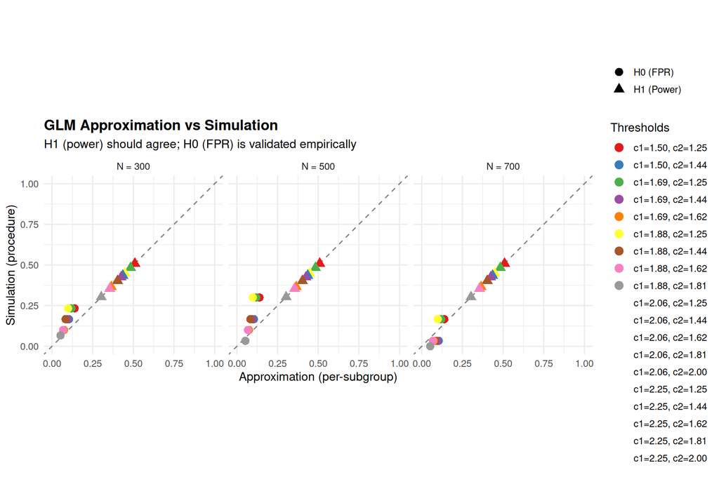

Approximation vs simulation for both H0 (circles) and H1 (triangles). Points near the diagonal indicate good agreement.

```r
oc_sim$H <- ifelse(oc_sim$has_hte, "H1 (Power)", "H0 (FPR)")
oc_sim$config <- sprintf("c1=%.2f, c2=%.2f", oc_sim$c1, oc_sim$c2)

ggplot(oc_sim, aes(x = approx, y = detect)) +
  geom_abline(slope = 1, intercept = 0, linetype = "dashed", colour = "grey50") +
  geom_point(aes(colour = config, shape = H), size = 3.5) +
  facet_wrap(~ paste("N =", n_total)) +
  scale_colour_brewer(palette = "Set1") +
  coord_equal(xlim = c(0, 1), ylim = c(0, 1)) +
  labs(x = "Approximation (per-subgroup)", y = "Simulation (procedure)",
       title = "GLM Approximation vs Simulation",
       subtitle = "H1 (power) should agree; H0 (FPR) is validated empirically",
       colour = "Thresholds", shape = NULL) +
  theme_minimal(base_size = 12) +
  theme(legend.position = "right", plot.title = element_text(face = "bold"))
```

## 5.4 Power vs FPR Tradeoff

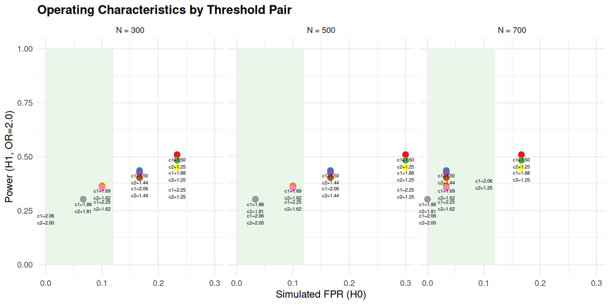

```r
tradeoff <- merge(
  oc_sim[has_hte == FALSE, .(n_total, c1, c2, FPR = detect)],
  oc_sim[has_hte == TRUE,  .(n_total, c1, c2, Power = detect)],
  by = c("n_total", "c1", "c2")
)
tradeoff$config <- sprintf("c1=%.2f\nc2=%.2f", tradeoff$c1, tradeoff$c2)

ggplot(tradeoff, aes(x = FPR, y = Power, label = config)) +
  geom_rect(aes(xmin = 0, xmax = fpr_target, ymin = 0, ymax = 1.0),
    fill = "#E8F5E9", alpha = 0.3, inherit.aes = FALSE) +
  geom_point(aes(colour = sprintf("c1=%.2f, c2=%.2f", c1, c2)), size = 3) +
  geom_text(size = 2, nudge_y = -0.04, check_overlap = TRUE) +
  facet_wrap(~ paste("N =", n_total)) +
  scale_colour_brewer(palette = "Set1") +
  labs(x = "Simulated FPR (H0)", y = sprintf("Power (H1, OR=%.1f)", theta_h1),
       title = "Operating Characteristics by Threshold Pair",
       colour = NULL) +
  theme_minimal(base_size = 12) +
  theme(legend.position = "none", plot.title = element_text(face = "bold"))
```

# 6 Part IV: Corrected Null Approximation

$$\text{FPR}_{\text{corrected}}(N) =
1 - (1 - P_1)^{L_{\text{eff}}(N)}$$

where $L_{\text{eff}}(N)$ is the effective number of approximately independent candidates evaluated by the procedure.

Key insight: $L_{\text{eff}}$ is a property of the candidate generation process (confounders, GRF, LASSO, maxk, n.min) — **not** of the thresholds $(c_1, c_2)$. The thresholds determine $P_1$; $L_{\text{eff}}$ determines how many times $P_1$ is “rolled.”

## 6.2 Implied $L_{\text{eff}}$ from Simulation

For each $(N, c_1, c_2)$ configuration, solve for the implied $L_{\text{eff}}$:

$$L_{\text{eff}} =
\frac{\log(1 - \text{FPR}_{\text{sim}})}
{\log(1 - P_1)}$$

```r
h0_data <- oc_sim[has_hte == FALSE & detect > 0]
h0_data[, L_eff := log(1 - detect) / log(1 - approx)]

# Summary by N: median and range of L_eff across threshold pairs
leff_by_N <- h0_data[, .(
  `Median L_eff` = round(median(L_eff, na.rm = TRUE), 2),
  `Min L_eff` = round(min(L_eff, na.rm = TRUE), 2),
  `Max L_eff` = round(max(L_eff, na.rm = TRUE), 2),
  n_configs = .N
), by = .(N = n_total)]

gt(leff_by_N) |>
  tab_header(
    title = "Implied L_eff by Sample Size",
    subtitle = "Across all (c1, c2) pairs.  Consistency supports L_eff as a candidate-count property."
  ) |>
  cols_label(N = "N", n_configs = "# Configs")
```

Implied L_eff at each N. If L_eff is a property of the candidate count, it should be approximately constant across threshold pairs at the same N.

Implied L_eff by Sample Size

Across all (c1, c2) pairs. Consistency supports L_eff as a candidate-count property.

| N | Median L_eff | Min L_eff | Max L_eff | # Configs |
| --- | --- | --- | --- | --- |
| 300 | 1.81 | 1.29 | 4.06 | 17 |
| 500 | 1.81 | 0.63 | 5.45 | 19 |
| 700 | 0.56 | 0.31 | 1.76 | 14 |

## 6.3 Fit the Power-Law Model

```r
# Use all H0 configurations for the fit
fit_data <- h0_data[, .(N = n_total, L_eff, c1, c2)]
fit_data[, ratio := N / n_min_val]

# Fit log-linear model on median L_eff per N
leff_medians <- fit_data[, .(L_eff_med = median(L_eff)), by = N]
leff_medians[, ratio := N / n_min_val]

fit_leff <- lm(log(L_eff_med) ~ log(ratio), data = leff_medians)
C_fit <- exp(coef(fit_leff)[1])
alpha_fit <- unname(coef(fit_leff)[2])
r2_fit <- summary(fit_leff)$r.squared

cat(sprintf("Fitted model: L_eff = %.3f * (N / %d)^%.3f\n",
            C_fit, n_min_val, alpha_fit))
```

```
#> Fitted model: L_eff = 16.489 * (N / 60)^-1.261
```

```r
cat(sprintf("R-squared: %.3f\n", r2_fit))
```

```
#> R-squared: 0.642
```

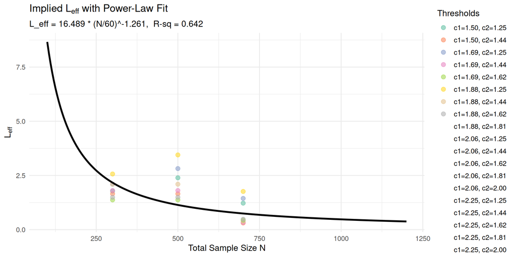

L_eff vs N with power-law fit. Points are individual (c1,c2) configurations; line is the fitted model.

```r
# Prediction curve
N_pred <- seq(100, 1200, by = 5)
pred_curve <- data.frame(
  N = N_pred,
  L_eff = C_fit * (N_pred / n_min_val)^alpha_fit
)

ggplot() +
  geom_point(data = fit_data, aes(x = N, y = L_eff, colour = sprintf("c1=%.2f, c2=%.2f", c1, c2)),
             alpha = 0.6, size = 2.5) +
  geom_line(data = pred_curve, aes(x = N, y = L_eff),
            colour = "black", linewidth = 1.2) +
  scale_colour_brewer(palette = "Set2") +
  labs(x = "Total Sample Size N",
       y = expression(L[eff]),
       title = expression("Implied " * L[eff] * " with Power-Law Fit"),
       subtitle = sprintf("L_eff = %.3f * (N/%d)^%.3f,  R-sq = %.3f",
                           C_fit, n_min_val, alpha_fit, r2_fit),
       colour = "Thresholds") +
  theme_minimal(base_size = 12) +
  theme(legend.position = "right",
        plot.title = element_text(face = "bold"))
```

## 6.4 Calibrate Using `calibrate_L_eff()`

```r
# Use the package function for formal calibration.
# Compute median P1 and median sim FPR at each N (across all threshold pairs)
# to ensure vectors are aligned.
cal_input <- h0_data[, .(
  P1_med      = median(approx, na.rm = TRUE),
  sim_fpr_med = median(detect, na.rm = TRUE)
), by = .(N = n_total)]
setorder(cal_input, N)

leff_cal <- calibrate_L_eff(
  N       = cal_input$N,
  P1      = cal_input$P1_med,
  sim_fpr = cal_input$sim_fpr_med,
  n_min   = n_min_val
)

print(leff_cal)
```

```
#> L_eff Calibration
#>   Model: L_eff = 74.168 * (N / 60)^-1.925
#>   R-squared: 0.629
#>   Calibrated at N = 300, 500, 700
#>
#>   Implied L_eff:
#>     N =  300: L_eff = 2.51 (fitted: 3.35)
#>     N =  500: L_eff = 2.58 (fitted: 1.25)
#>     N =  700: L_eff = 0.42 (fitted: 0.65)
```

```r
# Verify lm() and calibrate_L_eff() agree
cat(sprintf("\nConsistency check: lm() C=%.4f alpha=%.4f vs calibrate_L_eff() C=%.4f alpha=%.4f\n",
            C_fit, alpha_fit, leff_cal$C, leff_cal$alpha))
```

```
#>
#> Consistency check: lm() C=16.4885 alpha=-1.2606 vs calibrate_L_eff() C=74.1685 alpha=-1.9253
```

```r
# Save calibration to .rds for downstream documents (S1)
# Use calibrate_L_eff() output (the canonical package function)
save_leff_calibration(
  C = leff_cal$C,
  alpha = leff_cal$alpha,
  n_min = n_min_val,
  outcome_type = "binary",
  cal_data = cal_input,
  dgm_description = paste(
    "Binary DGM,", length(confounders_name), "confounders",
    paste0("(", paste(confounders_name, collapse = ", "), "),"),
    sprintf("p(event)=%.2f, %.0f%% harm prevalence",
            p_event, 100 * p_harm)),
  n_sims_per_N = nsims,
  output_dir = output_dir,
  extra = list(
    # ForestSearch config (S1 should match these)
    confounders_name = confounders_name,
    p_event          = p_event,
    p_harm           = p_harm,
    theta_h1         = theta_h1,
    pcons            = pcons,
    fs_splits        = fs_splits,
    maxk_val         = maxk_val,
    fpr_target       = fpr_target,
    N_cal_values     = N_cal_values,
    # Grid range validated for L_eff threshold-independence
    c1_range = range(c1_grid),
    c2_range = range(c2_grid)
  )
)
```

```
#> L_eff calibration saved: _data/calibration_binary_leff.rds
```

```
#>   outcome: binary | C = 74.1685 | alpha = -1.9253 | n_min = 60
```

```
#>   Size: 0.7 KB
```

## 6.5 Corrected Type-I Error Table

```r
h0_corr <- copy(h0_data)

# Apply correction using the fitted L_eff
h0_corr[, L_eff_fitted := C_fit * (n_total / n_min_val)^alpha_fit]
h0_corr[, fpr_corrected := 1 - (1 - approx)^L_eff_fitted]
h0_corr[, ratio_uncorrected := round(detect / pmax(approx, 0.001), 2)]
h0_corr[, ratio_corrected := round(detect / pmax(fpr_corrected, 0.001), 2)]

gt(h0_corr[, .(N = n_total, c1, c2,
               `P1 (uncorr)` = round(approx, 3),
               `FPR (corrected)` = round(fpr_corrected, 3),
               `Sim FPR` = round(detect, 3),
               `Sim/Uncorr` = ratio_uncorrected,
               `Sim/Corr` = ratio_corrected)]) |>
  tab_header(
    title = md("**Corrected vs Uncorrected Approximation (H0)**"),
    subtitle = sprintf("L_eff = %.3f * (N/%d)^%.3f",
                        C_fit, n_min_val, alpha_fit)
  ) |>
  tab_style(style = cell_fill(color = "#E8F5E9"),
    locations = cells_body(columns = `Sim/Corr`,
      rows = abs(`Sim/Corr` - 1) <= 0.3)) |>
  tab_style(style = cell_fill(color = "#FFF9C4"),
    locations = cells_body(columns = `Sim/Corr`,
      rows = abs(`Sim/Corr` - 1) > 0.3 & abs(`Sim/Corr` - 1) <= 0.6)) |>
  tab_row_group(label = "N = 700", rows = N == 700) |>
  tab_row_group(label = "N = 500", rows = N == 500) |>
  tab_row_group(label = "N = 300", rows = N == 300) |>
  tab_source_note(
    "Green: Sim/Corr within 30% of 1.0.  Yellow: 30-60% off."
  )
```

Corrected FPR vs simulation. Sim/Corrected should be closer to 1.0 than Sim/Uncorrected.

**Corrected vs Uncorrected Approximation (H0)**

L_eff = 16.489 * (N/60)^-1.261

| N | c1 | c2 | P1 (uncorr) | FPR (corrected) | Sim FPR | Sim/Uncorr | Sim/Corr |
| --- | --- | --- | --- | --- | --- | --- | --- |
| N = 300 |  |  |  |  |  |  |  |
| 300 | 1.50 | 1.25 | 0.139 | 0.276 | 0.233 | 1.68 | 0.84 |
| 300 | 1.69 | 1.25 | 0.119 | 0.240 | 0.233 | 1.96 | 0.97 |
| 300 | 1.88 | 1.25 | 0.098 | 0.201 | 0.233 | 2.37 | 1.16 |
| 300 | 2.06 | 1.25 | 0.080 | 0.165 | 0.233 | 2.92 | 1.41 |
| 300 | 2.25 | 1.25 | 0.063 | 0.132 | 0.233 | 3.68 | 1.76 |
| 300 | 1.50 | 1.44 | 0.104 | 0.213 | 0.167 | 1.60 | 0.78 |
| 300 | 1.69 | 1.44 | 0.096 | 0.197 | 0.167 | 1.74 | 0.85 |
| 300 | 1.88 | 1.44 | 0.083 | 0.172 | 0.167 | 2.00 | 0.97 |
| 300 | 2.06 | 1.44 | 0.070 | 0.146 | 0.167 | 2.38 | 1.14 |
| 300 | 2.25 | 1.44 | 0.057 | 0.119 | 0.167 | 2.93 | 1.40 |
| 300 | 1.69 | 1.62 | 0.074 | 0.153 | 0.100 | 1.35 | 0.65 |
| 300 | 1.88 | 1.62 | 0.068 | 0.142 | 0.100 | 1.47 | 0.70 |
| 300 | 2.06 | 1.62 | 0.060 | 0.125 | 0.100 | 1.67 | 0.80 |
| 300 | 2.25 | 1.62 | 0.050 | 0.106 | 0.100 | 1.99 | 0.95 |
| 300 | 1.88 | 1.81 | 0.052 | 0.109 | 0.067 | 1.28 | 0.61 |
| 300 | 2.06 | 1.81 | 0.048 | 0.102 | 0.067 | 1.38 | 0.65 |
| 300 | 2.25 | 1.81 | 0.042 | 0.090 | 0.067 | 1.57 | 0.74 |
| N = 500 |  |  |  |  |  |  |  |
| 500 | 1.50 | 1.25 | 0.139 | 0.156 | 0.300 | 2.17 | 1.92 |
| 500 | 1.69 | 1.25 | 0.119 | 0.134 | 0.300 | 2.52 | 2.24 |
| 500 | 1.88 | 1.25 | 0.098 | 0.111 | 0.300 | 3.05 | 2.70 |
| 500 | 2.06 | 1.25 | 0.080 | 0.091 | 0.300 | 3.75 | 3.31 |
| 500 | 2.25 | 1.25 | 0.063 | 0.072 | 0.300 | 4.73 | 4.17 |
| 500 | 1.50 | 1.44 | 0.104 | 0.118 | 0.167 | 1.60 | 1.41 |
| 500 | 1.69 | 1.44 | 0.096 | 0.109 | 0.167 | 1.74 | 1.53 |
| 500 | 1.88 | 1.44 | 0.083 | 0.094 | 0.167 | 2.00 | 1.77 |
| 500 | 2.06 | 1.44 | 0.070 | 0.079 | 0.167 | 2.38 | 2.10 |
| 500 | 2.25 | 1.44 | 0.057 | 0.065 | 0.167 | 2.93 | 2.58 |
| 500 | 1.69 | 1.62 | 0.074 | 0.084 | 0.100 | 1.35 | 1.19 |
| 500 | 1.88 | 1.62 | 0.068 | 0.077 | 0.100 | 1.47 | 1.29 |
| 500 | 2.06 | 1.62 | 0.060 | 0.068 | 0.100 | 1.67 | 1.48 |
| 500 | 2.25 | 1.62 | 0.050 | 0.057 | 0.100 | 1.99 | 1.76 |
| 500 | 1.88 | 1.81 | 0.052 | 0.059 | 0.033 | 0.64 | 0.56 |
| 500 | 2.06 | 1.81 | 0.048 | 0.055 | 0.033 | 0.69 | 0.61 |
| 500 | 2.25 | 1.81 | 0.042 | 0.048 | 0.033 | 0.79 | 0.69 |
| 500 | 2.06 | 2.00 | 0.037 | 0.042 | 0.033 | 0.90 | 0.79 |
| 500 | 2.25 | 2.00 | 0.035 | 0.039 | 0.033 | 0.97 | 0.85 |
| N = 700 |  |  |  |  |  |  |  |
| 700 | 1.50 | 1.25 | 0.139 | 0.105 | 0.167 | 1.20 | 1.58 |
| 700 | 1.69 | 1.25 | 0.119 | 0.090 | 0.167 | 1.40 | 1.85 |
| 700 | 1.88 | 1.25 | 0.098 | 0.074 | 0.167 | 1.70 | 2.25 |
| 700 | 2.06 | 1.25 | 0.080 | 0.060 | 0.100 | 1.25 | 1.66 |
| 700 | 2.25 | 1.25 | 0.063 | 0.048 | 0.100 | 1.58 | 2.10 |
| 700 | 1.50 | 1.44 | 0.104 | 0.079 | 0.033 | 0.32 | 0.42 |
| 700 | 1.69 | 1.44 | 0.096 | 0.072 | 0.033 | 0.35 | 0.46 |
| 700 | 1.88 | 1.44 | 0.083 | 0.063 | 0.033 | 0.40 | 0.53 |
| 700 | 2.06 | 1.44 | 0.070 | 0.053 | 0.033 | 0.48 | 0.63 |
| 700 | 2.25 | 1.44 | 0.057 | 0.043 | 0.033 | 0.59 | 0.78 |
| 700 | 1.69 | 1.62 | 0.074 | 0.056 | 0.033 | 0.45 | 0.60 |
| 700 | 1.88 | 1.62 | 0.068 | 0.051 | 0.033 | 0.49 | 0.65 |
| 700 | 2.06 | 1.62 | 0.060 | 0.045 | 0.033 | 0.56 | 0.74 |
| 700 | 2.25 | 1.62 | 0.050 | 0.038 | 0.033 | 0.66 | 0.89 |

Green: Sim/Corr within 30% of 1.0. Yellow: 30-60% off.

## 6.6 Corrected Scatter Plot

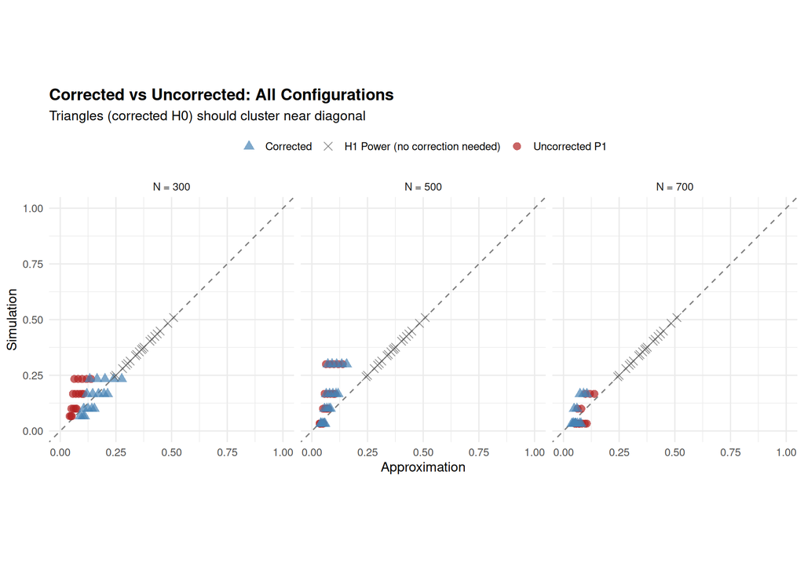

Corrected (triangles) vs uncorrected (circles) approximation against simulation. Under H0, corrected points should move toward the diagonal.

```r
# Build comparison data for H0 only
scatter_corr <- rbind(
  h0_corr[, .(N = n_total, Approx = approx, Sim = detect,
              Method = "Uncorrected P1",
              config = sprintf("c1=%.2f, c2=%.2f", c1, c2))],
  h0_corr[, .(N = n_total, Approx = fpr_corrected, Sim = detect,
              Method = "Corrected",
              config = sprintf("c1=%.2f, c2=%.2f", c1, c2))]
)

# Add H1 points (uncorrected only --- correction not needed for power)
h1_scatter <- oc_sim[has_hte == TRUE,
  .(N = n_total, Approx = approx, Sim = detect,
    Method = "H1 Power (no correction needed)",
    config = sprintf("c1=%.2f, c2=%.2f", c1, c2))]

scatter_all <- rbind(scatter_corr, h1_scatter)

ggplot(scatter_all, aes(x = Approx, y = Sim)) +
  geom_abline(slope = 1, intercept = 0, linetype = "dashed",
              colour = "grey50") +
  geom_point(aes(colour = Method, shape = Method), size = 3, alpha = 0.7) +
  scale_shape_manual(values = c("Uncorrected P1" = 16,
                                 "Corrected" = 17,
                                 "H1 Power (no correction needed)" = 4)) +
  scale_colour_manual(values = c("Uncorrected P1" = "firebrick",
                                  "Corrected" = "steelblue",
                                  "H1 Power (no correction needed)" = "grey40")) +
  facet_wrap(~ paste("N =", N)) +
  coord_equal(xlim = c(0, 1), ylim = c(0, 1)) +
  labs(x = "Approximation", y = "Simulation",
       title = "Corrected vs Uncorrected: All Configurations",
       subtitle = "Triangles (corrected H0) should cluster near diagonal",
       colour = NULL, shape = NULL) +
  theme_minimal(base_size = 12) +
  theme(legend.position = "top",
        plot.title = element_text(face = "bold"))
```

## 6.7 Corrected Power-FPR Tradeoff

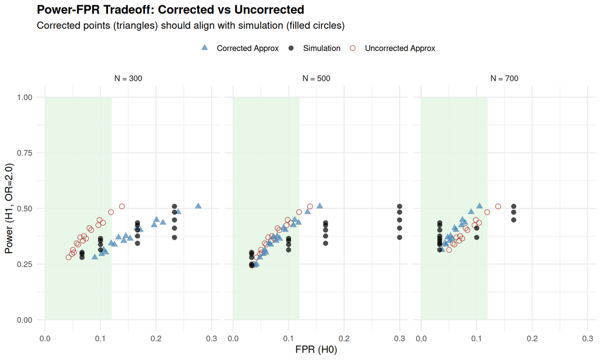

```r
# Build tradeoff with corrected FPR
tradeoff_corr <- merge(
  h0_corr[, .(n_total, c1, c2,
              FPR_uncorr = approx,
              FPR_corr = fpr_corrected,
              FPR_sim = detect)],
  oc_sim[has_hte == TRUE, .(n_total, c1, c2, Power = detect)],
  by = c("n_total", "c1", "c2")
)

tradeoff_long <- rbind(
  tradeoff_corr[, .(N = n_total, c1, c2,
                    FPR = FPR_uncorr, Power,
                    Source = "Uncorrected Approx")],
  tradeoff_corr[, .(N = n_total, c1, c2,
                    FPR = FPR_corr, Power,
                    Source = "Corrected Approx")],
  tradeoff_corr[, .(N = n_total, c1, c2,
                    FPR = FPR_sim, Power,
                    Source = "Simulation")]
)
tradeoff_long$config <- sprintf("c1=%.2f, c2=%.2f",
                                 tradeoff_long$c1, tradeoff_long$c2)

ggplot(tradeoff_long, aes(x = FPR, y = Power)) +
  geom_rect(aes(xmin = 0, xmax = fpr_target, ymin = 0, ymax = 1.0),
    fill = "#E8F5E9", alpha = 0.2, inherit.aes = FALSE) +
  geom_point(aes(colour = Source, shape = Source), size = 2.5, alpha = 0.7) +
  scale_shape_manual(values = c("Uncorrected Approx" = 1,
                                 "Corrected Approx" = 17,
                                 "Simulation" = 16)) +
  scale_colour_manual(values = c("Uncorrected Approx" = "firebrick",
                                  "Corrected Approx" = "steelblue",
                                  "Simulation" = "black")) +
  facet_wrap(~ paste("N =", N)) +
  labs(x = "FPR (H0)", y = sprintf("Power (H1, OR=%.1f)", theta_h1),
       title = "Power-FPR Tradeoff: Corrected vs Uncorrected",
       subtitle = "Corrected points (triangles) should align with simulation (filled circles)",
       colour = NULL, shape = NULL) +
  theme_minimal(base_size = 12) +
  theme(legend.position = "top",
        plot.title = element_text(face = "bold"))
```

## 6.8 Corrected Threshold Recommendations

Using the corrected approximation, identify thresholds where the **corrected** FPR is at most 12%.

```r
# Use corrected FPR for recommendations
rec_corr <- tradeoff_corr[, .(
  N = n_total, c1, c2,
  `Corr FPR` = round(FPR_corr, 3),
  `Sim FPR` = round(FPR_sim, 3),
  `Sim Power` = round(Power, 3)
)]

# Acceptable: corrected FPR <= target (power is informational only)
acceptable_corr <- rec_corr[`Corr FPR` <= fpr_target]

if (nrow(acceptable_corr) > 0) {
  setorder(acceptable_corr, N, `Corr FPR`)
  gt(acceptable_corr) |>
    tab_header(
      title = md("**Corrected-Approximation Threshold Recommendations**"),
      subtitle = sprintf("L_eff = %.3f * (N/%d)^%.3f | pcons = %.2f",
                          C_fit, n_min_val, alpha_fit, pcons)
    ) |>
    tab_row_group(label = "N = 700", rows = N == 700) |>
    tab_row_group(label = "N = 500", rows = N == 500) |>
    tab_row_group(label = "N = 300", rows = N == 300) |>
    tab_source_note(sprintf(
      "Selection criterion: Corr FPR <= %.0f%%. Power is shown for reference only.",
      100 * fpr_target))
} else {
  cat(sprintf("No configurations met Corr FPR <= %.0f%%.\n\n",
              100 * fpr_target))

  # Show the closest pairs
  setorder(rec_corr, `Corr FPR`)
  n_show <- min(5, nrow(rec_corr))
  cat(sprintf("Closest %d configurations:\n", n_show))

  gt(rec_corr[seq_len(n_show)]) |>
    tab_header(
      title = md(sprintf(
        "**Nearest Configurations (target: Corr FPR <= %.0f%%)**",
        100 * fpr_target)),
      subtitle = "Consider the suggestions below to achieve the target."
    )

  best_fpr <- rec_corr$`Corr FPR`[1]
  cat(sprintf("\nBest achievable Corr FPR: %.1f%% (target: %.0f%%)\n",
              100 * best_fpr, 100 * fpr_target))
  cat("\nSuggestions:\n")
  cat("  1. Expand the threshold grid in the setup chunk:\n")
  cat(sprintf("     Current: c1_grid = seq(%.2f, %.2f, by = 0.05)\n",
              min(c1_grid), max(c1_grid)))
  cat(sprintf("              c2_grid = seq(%.2f, %.2f, by = 0.05)\n",
              min(c2_grid), max(c2_grid)))
  cat(sprintf("     Try:     c1_grid = seq(%.2f, %.2f, by = 0.05)\n",
              min(c1_grid), max(c1_grid) + 0.30))
  cat(sprintf("              c2_grid = seq(%.2f, %.2f, by = 0.05)\n",
              min(c2_grid), max(c2_grid) + 0.30))
  cat("  2. Both c1 and c2 contribute: raising c2 tightens\n")
  cat("     consistency; raising c1 tightens screening.\n")
  cat("     Typically c2 has a larger effect on FPR at the\n")
  cat("     same increment.\n")
  if (best_fpr - fpr_target < 0.05) {
    cat("  3. The gap is small -- finer resolution (by = 0.02)\n")
    cat("     may find viable pairs within the current range.\n")
  }
}
```

Threshold recommendations using corrected FPR.

**Corrected-Approximation Threshold Recommendations**

L_eff = 16.489 * (N/60)^-1.261 | pcons = 0.90

| N | c1 | c2 | Corr FPR | Sim FPR | Sim Power |
| --- | --- | --- | --- | --- | --- |
| N = 300 |  |  |  |  |  |
| 300 | 2.25 | 1.81 | 0.090 | 0.067 | 0.280 |
| 300 | 2.06 | 1.81 | 0.102 | 0.067 | 0.295 |
| 300 | 2.25 | 1.62 | 0.106 | 0.100 | 0.314 |
| 300 | 1.88 | 1.81 | 0.109 | 0.067 | 0.303 |
| 300 | 2.25 | 1.44 | 0.119 | 0.167 | 0.343 |
| N = 500 |  |  |  |  |  |
| 500 | 2.25 | 2.00 | 0.039 | 0.033 | 0.244 |
| 500 | 2.06 | 2.00 | 0.042 | 0.033 | 0.250 |
| 500 | 2.25 | 1.81 | 0.048 | 0.033 | 0.280 |
| 500 | 2.06 | 1.81 | 0.055 | 0.033 | 0.295 |
| 500 | 2.25 | 1.62 | 0.057 | 0.100 | 0.314 |
| 500 | 1.88 | 1.81 | 0.059 | 0.033 | 0.303 |
| 500 | 2.25 | 1.44 | 0.065 | 0.167 | 0.343 |
| 500 | 2.06 | 1.62 | 0.068 | 0.100 | 0.338 |
| 500 | 2.25 | 1.25 | 0.072 | 0.300 | 0.370 |
| 500 | 1.88 | 1.62 | 0.077 | 0.100 | 0.355 |
| 500 | 2.06 | 1.44 | 0.079 | 0.167 | 0.376 |
| 500 | 1.69 | 1.62 | 0.084 | 0.100 | 0.365 |
| 500 | 2.06 | 1.25 | 0.091 | 0.300 | 0.411 |
| 500 | 1.88 | 1.44 | 0.094 | 0.167 | 0.403 |
| 500 | 1.69 | 1.44 | 0.109 | 0.167 | 0.425 |
| 500 | 1.88 | 1.25 | 0.111 | 0.300 | 0.448 |
| 500 | 1.50 | 1.44 | 0.118 | 0.167 | 0.436 |
| N = 700 |  |  |  |  |  |
| 700 | 2.25 | 1.62 | 0.038 | 0.033 | 0.314 |
| 700 | 2.25 | 1.44 | 0.043 | 0.033 | 0.343 |
| 700 | 2.06 | 1.62 | 0.045 | 0.033 | 0.338 |
| 700 | 2.25 | 1.25 | 0.048 | 0.100 | 0.370 |
| 700 | 1.88 | 1.62 | 0.051 | 0.033 | 0.355 |
| 700 | 2.06 | 1.44 | 0.053 | 0.033 | 0.376 |
| 700 | 1.69 | 1.62 | 0.056 | 0.033 | 0.365 |
| 700 | 2.06 | 1.25 | 0.060 | 0.100 | 0.411 |
| 700 | 1.88 | 1.44 | 0.063 | 0.033 | 0.403 |
| 700 | 1.69 | 1.44 | 0.072 | 0.033 | 0.425 |
| 700 | 1.88 | 1.25 | 0.074 | 0.167 | 0.448 |
| 700 | 1.50 | 1.44 | 0.079 | 0.033 | 0.436 |
| 700 | 1.69 | 1.25 | 0.090 | 0.167 | 0.483 |
| 700 | 1.50 | 1.25 | 0.105 | 0.167 | 0.509 |

Selection criterion: Corr FPR <= 12%. Power is shown for reference only.